# DAR CW 1

#### (b) Plot the response and the predictor. Use the abline() function to display the least squares regression line.

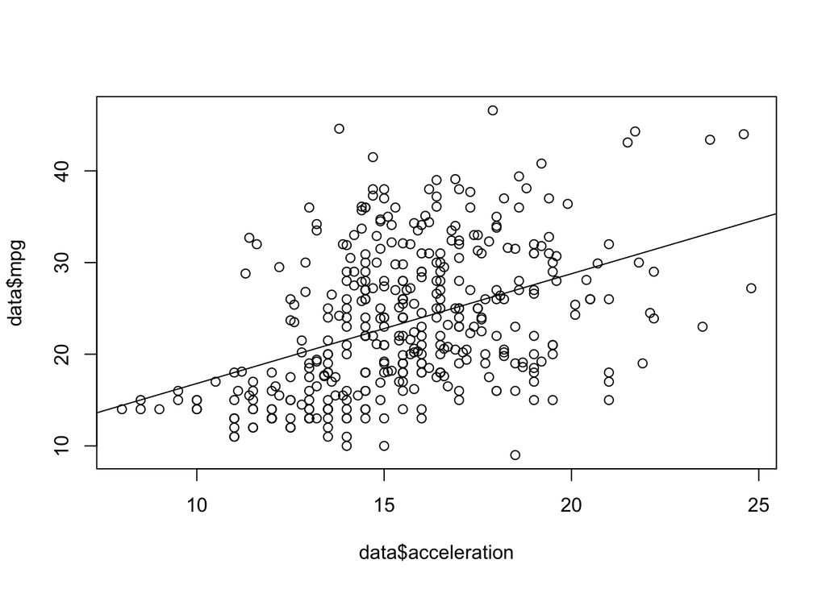

```r
plot(data$acceleration, data$mpg)
abline(lm.fit)
```

#### (c) Plot the 97% confidence interval and prediction interval in the same plot as (b) using different colours and legends.

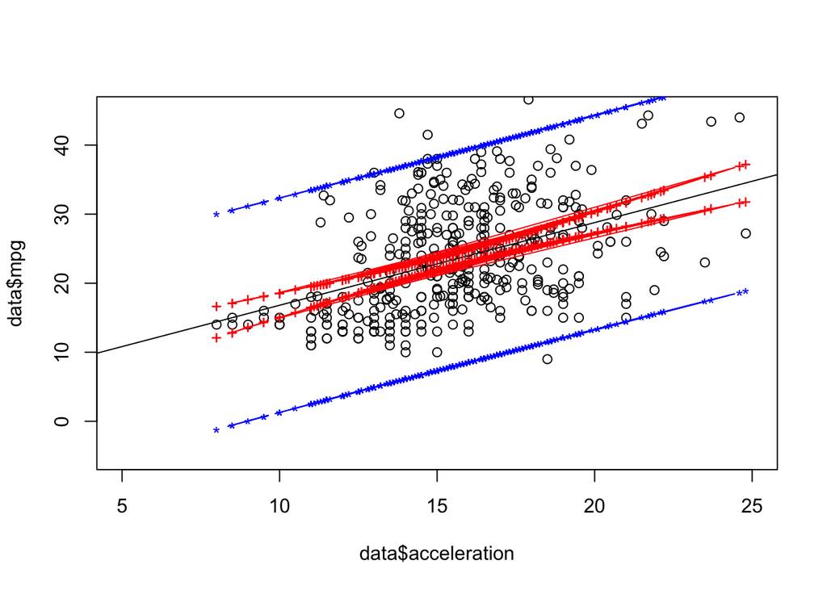

```r
lm.fit.accel=lm(mpg~acceleration,data=data)
nd <- data.frame(acceleration = data$acceleration)
ci_predict <- predict(lm.fit.accel,interval="confidence",level=0.97, newdata=nd)
pi_predict <- predict(lm.fit.accel,interval="predict",level=0.97,newdata=nd)
plot(data$acceleration,data$mpg, ylim=c(-5,45),xlim=c(5,25))
abline(lm.fit.accel)
lines(nd$acceleration, ci_predict[,"lwr"], col="red", type="b", pch="+")
lines(nd$acceleration, ci_predict[,"upr"], col="red", type="b", pch="+")
lines(nd$acceleration, pi_predict[,"upr"], col="blue", type="b", pch="*")
lines(nd$acceleration, pi_predict[,"lwr"], col="blue", type="b", pch="*")
```

The blue lines show the predicted interval lower and upper bounds whereas the red lines show confidence interval lower and upper bounds.

### 5. Logistic regression and cross validation

A recent study has shown that the accurate prediction of the office room occupancy leads to potential energy savings of 30%. In this question, you are required to build logistic regression models by using different environmental measurements as predictors (features), such as temperature, humidity, light, CO2 and humidity ratio, to predict the office room occupancy. The provided training dataset consists of 2,000 observations, whilst the testing dataset consists of 300 observations.

#### (a) Load the training and testing datasets from corresponding files, and display the statistics about different predictors in the training dataset.

```r
training_set <- read.table('Room_Occupancy_Training_set.txt', header=TRUE, sep = ',')
testing_set <- read.table('Room_Occupancy_Testing_set.txt', header=TRUE, sep = ',')
dim(training_set)
```

```
[1] 2000    6
```

```r
str(training_set)
```

```
'data.frame':   2000 obs. of  6 variables:
 $ Temperature  : num  23.2 23.1 23.1 23.1 23.1 ...
 $ Humidity     : num  27.3 27.3 27.2 27.2 27.2 ...
 $ Light        : num  426 430 426 426 426 ...
 $ CO2          : num  721 714 714 708 704 ...
 $ HumidityRatio: num  0.00479 0.00478 0.00478 0.00477 0.00476 ...
 $ Occupancy    : int  1 1 1 1 1 1 1 1 1 1 ...
```

```r
summary(training_set)
```

```
  Temperature       Humidity         Light            CO2
 Min.   :20.10   Min.   :18.96   Min.   :  0.0   Min.   : 426.0
 1st Qu.:20.89   1st Qu.:21.82   1st Qu.:  0.0   1st Qu.: 448.0
 Median :21.20   Median :25.00   Median :  0.0   Median : 485.5
 Mean   :21.42   Mean   :24.22   Mean   :144.7   Mean   : 634.6
 3rd Qu.:22.10   3rd Qu.:26.29   3rd Qu.:433.0   3rd Qu.: 845.8
 Max.   :23.18   Max.   :28.50   Max.   :744.0   Max.   :1139.0
 HumidityRatio        Occupancy
 Min.   :0.002824   Min.   :0.0000
 1st Qu.:0.003375   1st Qu.:0.0000
 Median :0.003905   Median :0.0000
 Mean   :0.003836   Mean   :0.2775
 3rd Qu.:0.004343   3rd Qu.:1.0000
 Max.   :0.004817   Max.   :1.0000
```

#### (b) Conduct a 10-fold cross validation to evaluate the predictive accuracy of a logistic regression model that uses Temperature as the only predictor. Report the average accuracy and AUROC value obtained over the 10-fold cross validation. Set the value of random seed as “100” when generating fold indices.Consider the predictive label equals to 1, if the predictive probability is greater than 0.5.

```r
library(caret)
library(ROCR)
accuracy_value <- as.numeric()
auroc_value_temp <- as.numeric()
set.seed(100)
training_folds <- createFolds(y=training_set[,6],k=10)

for(i in 1:10){
    fold_cv_train <- training_set[training_folds[[i]],]
    fold_cv_test <- training_set[-training_folds[[i]],]
    trained_model_temp <- glm(Occupancy  ~ Temperature, data = fold_cv_train, family = binomial)
    pred_prob_temp <- predict(trained_model_temp, fold_cv_test, type='response')

    glm.pred <- rep(1,dim(fold_cv_test)[1])
    glm.pred[pred_prob_temp<.5] <- 0

    accuracy_fold <- mean(glm.pred == fold_cv_test$Occupancy)
    accuracy_value <- append(accuracy_value, accuracy_fold)

    pr_temp <- prediction(pred_prob_temp, fold_cv_test$Occupancy)
    auroc_temp <- performance(pr_temp, measure = "auc")
    auroc_temp <- auroc_temp@y.values[[1]]
    auroc_value_temp<- append(auroc_value_temp,auroc_temp)

}
cat('average accuracy value: ', mean(accuracy_value))
```

```
average accuracy value:  0.8411667
```

```r
cat('average AUROC value: ', mean(auroc_value_temp))
```

```
average AUROC value:  0.8695995
```

#### (c) Conduct a 10-fold cross validation to evaluate the predictive accuracy of a logistic regression model that uses HumidityRatio as the only predictor. Report the average accuracy and AUROC value obtained over the 10-fold cross validation. Set the value of random seed as “100” when generating fold indices. Consider the predictive label equals to 1, if the predictive probability is greater than 0.5.

```r
accuracy_value <- as.numeric()
auroc_value_hum <- as.numeric()
set.seed(100)
training_folds <- createFolds(y=training_set[,6],k=10)

for(i in 1:10){
    fold_cv_test <- training_set[training_folds[[i]],]
    fold_cv_train <- training_set[-training_folds[[i]],]
    trained_model_hum <- glm(Occupancy  ~ HumidityRatio, data = fold_cv_train, family = binomial)
    pred_prob_hum <- predict(trained_model_hum, fold_cv_test, type='response')

    glm.pred <- rep(1,dim(fold_cv_test)[1])
    glm.pred[pred_prob_hum<.5] <- 0
    accuracy_fold <- mean(glm.pred == fold_cv_test$Occupancy)
    accuracy_value <- append(accuracy_value, accuracy_fold)

    pr_hum <- prediction(pred_prob_hum, fold_cv_test$Occupancy)
    auroc_hum <- performance(pr_hum, measure = "auc")
    auroc_hum <- auroc_hum@y.values[[1]]
    auroc_value_hum<- append(auroc_value_hum,auroc_hum)

}
cat('average accuracy value: ', mean(accuracy_value))
```

```
average accuracy value:  0.7825
```

```r
cat('average AUROC value: ', mean(auroc_value_hum))
```

```
average AUROC value:  0.8384153
```

#### (d) Conduct a 10-fold cross validation to evaluate the predictive accuracy of a logistic regression model that uses Temperature and HumidityRatio in the training dataset. Report the average accuracy and AUROC value obtained over the 10-fold cross validation. Set the value of random seed as “100” when generating fold indices. Consider the predictive label equals to 1, if the predictive probability is greater than 0.5.

```r
accuracy_value <- as.numeric()
auroc_value_hum_temp <- as.numeric()
set.seed(100)
training_folds <- createFolds(y=training_set[,6],k=10)

for(i in 1:10){
    fold_cv_test <- training_set[training_folds[[i]],]
    fold_cv_train <- training_set[-training_folds[[i]],]
    trained_model_hum_temp <- glm(Occupancy  ~ HumidityRatio + Temperature, data = fold_cv_train, family = binomial)
    pred_prob_hum_temp <- predict(trained_model_hum_temp, fold_cv_test, type='response')

    glm.pred <- rep(1,dim(fold_cv_test)[1])
    glm.pred[pred_prob_hum_temp<.5] <- 0
    accuracy_fold <- mean(glm.pred == fold_cv_test$Occupancy)
    accuracy_value <- append(accuracy_value, accuracy_fold)

    pr_hum_temp <- prediction(pred_prob_hum_temp, fold_cv_test$Occupancy)
    auroc_hum_temp <- performance(pr_hum_temp, measure = "auc")
    auroc_hum_temp <- auroc_hum_temp@y.values[[1]]
    auroc_value_hum_temp<- append(auroc_value_hum_temp,auroc_hum_temp)

}
cat('average accuracy value: ', mean(accuracy_value))
```

```
average accuracy value:  0.855
```

```r
cat('average AUROC value: ', mean(auroc_value_hum_temp))
```

```
average AUROC value:  0.8718627
```

#### (e) Compare the performance of those three different models on predicting the testing dataset. Draw ROC curves for all individual models and calculating the corresponding AUROC values.

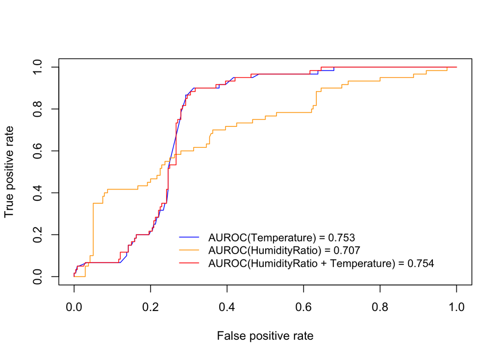

```r
# Train the three models
trained_model_1 <- glm(Occupancy  ~ Temperature, data = training_set, family = binomial)
trained_model_2 <- glm(Occupancy  ~ HumidityRatio, data = training_set, family = binomial)
trained_model_3 <- glm(Occupancy  ~ Temperature+HumidityRatio, data = training_set, family = binomial)

prediction_trained_model_1 <- predict(trained_model_1, testing_set, type='response')
prediction_trained_model_2 <- predict(trained_model_2, testing_set, type='response')
prediction_trained_model_3 <- predict(trained_model_3, testing_set, type='response')

pr_trained_model_1 <- prediction(prediction_trained_model_1, testing_set$Occupancy)
pr_trained_model_2 <- prediction(prediction_trained_model_2, testing_set$Occupancy)
pr_trained_model_3 <- prediction(prediction_trained_model_3, testing_set$Occupancy)

# Calculate the AUROC values obtained by different models.
auroc_trained_model_1 <- performance(pr_trained_model_1, measure = "auc")
auroc_trained_model_2 <- performance(pr_trained_model_2, measure = "auc")
auroc_trained_model_3 <- performance(pr_trained_model_3, measure = "auc")
auroc_trained_model_value_1 <- auroc_trained_model_1@y.values[[1]]
auroc_trained_model_value_2 <- auroc_trained_model_2@y.values[[1]]
auroc_trained_model_value_3 <- auroc_trained_model_3@y.values[[1]]

# Get the True positive rate and False positive rate
prf_trained_model_1 <- performance(pr_trained_model_1, measure = "tpr", x.measure = "fpr")
prf_trained_model_2 <- performance(pr_trained_model_2, measure = "tpr", x.measure = "fpr")
prf_trained_model_3 <- performance(pr_trained_model_3, measure = "tpr", x.measure = "fpr")
# Plot findings
plot(prf_trained_model_1, col="blue")
plot(prf_trained_model_2, col="orange", add=TRUE)
plot(prf_trained_model_3, col="red", add=TRUE)
legend(0.25,0.25, c(text=sprintf('AUROC(Temperature) = %s',round(auroc_trained_model_value_1, digits=3)),
text=sprintf('AUROC(HumidityRatio) = %s',round(auroc_trained_model_value_2, digits=3)),
text=sprintf('AUROC(HumidityRatio + Temperature) = %s',round(auroc_trained_model_value_3, digits=3))),
lty=1, cex=0.9, col = c("blue", "orange", "red"), bty="n", y.intersp=1, inset=c(0.1,-0.15))
```